# Zindi Challenge - Credit Scoring

# Linear Discrimination Analysis

This alternative classification approach has more of a Bayesian feel to it in that it involves finding a reliable estimate of a posterior probability function. We are still interested in Pr[Y = k|X = x] (given that we know a bunch of covariates about an individual denoted as X, what is the probability that they default on credit payments denoted as Y):

Firstly a prior probability must be calculated which will be denoted as $\pi_{k}$ (which essentially quantifies our initial expectation of an individual defaulting and an individual not defaulting). Secondly a likelihood function must also be defined which says, given that a customer has defaulted what is the probability that customer had this particular set of covariates:

$$f_{k} (x) = Pr[X|Y = k]$$

Certain assumption need to be made in order for us to estimate $f_{k} (x)$ (the most common assumption is that the covariates come from a multivariate gaussian which would make $f_{k} (x)$ a multivariate normal function). Then the posterior probability ends up looking something like this:

$$Pr[Y = k| X = x] = \frac{\pi_{k} f_{k}(x)}{\sum_{l = 1}^{k} \pi_{l}
f_{l} (x)}$$

```r
# Linear Discriminant Analysis
library(MASS)
lda_train = lda(IsDefaulted ~ ., data = train_input)

lda_train
```

```
## Call:
## lda(IsDefaulted ~ ., data = train_input)
##
## Prior probabilities of groups:
##         0         1
## 0.9331307 0.0668693
##
## Group means:
##   CustomerId      Value  ProductId ThirdPartyId      BatchId InvestorId
## 0 0.11900128 -0.2100566 -0.2484401 -0.001739469 -0.009775015 -0.2469775
## 1 0.05949758  1.0661852  1.0459416 -0.087567535  0.841121845  0.9267387
##        LoanId LoanApplicationId    IssueDay IssueMonth TransactionDay
## 0  0.04129024       -0.01457112 -0.01972388  0.2810263    -0.01977143
## 1 -0.38408624       -0.16260641 -0.07710358 -0.3913848    -0.07703245
##   TransactionMonth
## 0        0.2810263
## 1       -0.3913848
##
## Coefficients of linear discriminants:
##                           LD1
## CustomerId         0.17130952
## Value              2.67424530
## ProductId         -0.19566959
## ThirdPartyId      -0.03769888
## BatchId           -0.06251780
## InvestorId        -0.07252374
## LoanId            -0.11920198
## LoanApplicationId  0.06336046
## IssueDay           6.32724566
## IssueMonth        -0.00665545
## TransactionDay    -6.32724493
## TransactionMonth  -0.00665545
```

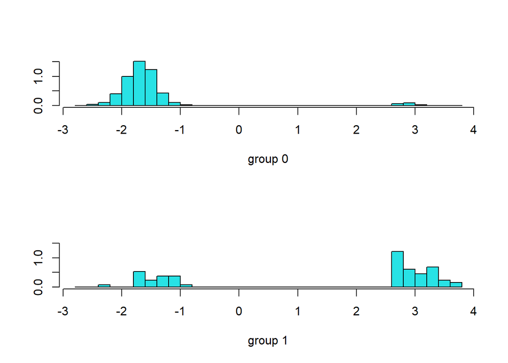

```r
lda_train %>% plot()
```

In-sample confusion matrix:

```r
lda_train_probs = predict(lda_train, train_input) # predicted training probs.

our_lda = lda_train_probs$class

table(our_lda, train_input$IsDefaulted) # in-sample confusion matrix
```

```
##
## our_lda   0   1
##       0 890  22
##       1  31  44
```

In-sample classification accuracy:

```r
mean(our_lda == train_input$IsDefaulted)
```

```
## [1] 0.9463019
```

# Naive Bayes

Naive bayes method shares similarities with the LDA method, in that the expression for the posterior probability is the same:

$$Pr[Y=k|X=x] =
\frac{\pi_{k}\mathbf{x}f_{k1}(x_{1})\mathbf{x}f_{k2}(x_{2})\mathbf{x}......\mathbf{x}f_{kp}(x_{p})}{\sum_{l=1}^{k}
\pi_{l}\mathbf{x}f_{l1}(x_{1})\mathbf{x}f_{l2}(x_{2})\mathbf{x}.....\mathbf{x}f_{lp}(x_{p})}$$

Instead naive bayes makes the assumption that within the $k^{th}$ class, the p predictors/covariates are independent. where:

$f_{kn}$ represents the likelihood function for the $k^{th}$ class/outcome and the $n^{th}$ predictor

$\pi_{l}$ represents the prior probability for the $l^{th}$ class/outcome

Out from naive bayes:

```r
# Naive-bayes
library(e1071)

nb_train = naiveBayes(IsDefaulted ~ ., data = train_input)

nb_train
```

```
##
## Naive Bayes Classifier for Discrete Predictors
##
## Call:
## naiveBayes.default(x = X, y = Y, laplace = laplace)
##
## A-priori probabilities:
## Y
##         0         1
## 0.9331307 0.0668693
##
## Conditional probabilities:
##    CustomerId
## Y         [,1]      [,2]
##   0 0.11900128 0.9847586
##   1 0.05949758 1.2617963
##
##    Value
## Y         [,1]      [,2]
##   0 -0.2100566 0.3674393
##   1  1.0661852 0.9483671
##
##    ProductId
## Y         [,1]      [,2]
##   0 -0.2484401 0.7475528
##   1  1.0459416 1.1983366
##
##    ThirdPartyId
## Y           [,1]     [,2]
##   0 -0.001739469 1.000423
##   1 -0.087567535 1.036452
##
##    BatchId
## Y           [,1]      [,2]
##   0 -0.009775015 0.9884738
##   1  0.841121845 1.0795763
##
##    InvestorId
## Y         [,1]      [,2]
##   0 -0.2469775 0.8374798
```

[output cut: 16 more lines]

```
##
##    IssueMonth
## Y         [,1]      [,2]
##   0  0.2810263 1.1648495
##   1 -0.3913848 0.7139396
##
##    TransactionDay
## Y          [,1]      [,2]
##   0 -0.01977143 0.9896223
##   1 -0.07703245 0.6369537
##
##    TransactionMonth
## Y         [,1]      [,2]
##   0  0.2810263 1.1648495
##   1 -0.3913848 0.7139396
```

In-sample confusion matrix:

```r
our_nb_train = predict(nb_train, train_input)

table(our_nb_train, train_input$IsDefaulted)
```

```
##
## our_nb_train   0   1
##            0 879  22
##            1  42  44
```

In-sample classification accuracy:

```r
mean(our_nb_train==train_input$IsDefaulted)
```

```
## [1] 0.935157
```

# Generalized-Additive-Models/GAMS

Recall a logisitic regression:

$$log(\frac{P(X)}{1-P(X)}) = \beta_{0} + \beta_{1}X_{1}+
\beta_{2}X_{2}+....+\beta_{p}X_{p}$$
It can be extended to allow for non-linear relationships between each predictor and the target variable by substituting a non-linear function $f_{j}(x_{ij})$ for the linear function $x_{ij}$:

$$log(\frac{P(X)}{1-P(X)}) = \beta_{0} + f_{1}(X_{1}) +
f_{2}(X_{2})+....+f_{p}(X_{p}))$$

```r
library(akima)
library(gam)
train_gam = gam(IsDefaulted ~ ., family = binomial, data = train_input)

summary(train_gam)
```

```
##
## Call: gam(formula = IsDefaulted ~ ., family = binomial, data = train_input)
## Deviance Residuals:
##     Min      1Q  Median      3Q     Max
## -1.4441 -0.2480 -0.1848 -0.1218  3.3963
##
## (Dispersion Parameter for binomial family taken to be 1)
##
##     Null Deviance: 484.5468 on 986 degrees of freedom
## Residual Deviance: 283.2115 on 975 degrees of freedom
## AIC: 307.2115
##
## Number of Local Scoring Iterations: 11
##
## Anova for Parametric Effects
##                    Df  Sum Sq Mean Sq F value    Pr(>F)
## CustomerId          1   14.50  14.497 12.4280 0.0004426 ***
## Value               1  112.93 112.931 96.8118 < 2.2e-16 ***
## ProductId           1    5.24   5.243  4.4946 0.0342543 *
## ThirdPartyId        1    0.23   0.233  0.1997 0.6550510
## BatchId             1    1.09   1.090  0.9341 0.3340272
## InvestorId          1    0.21   0.207  0.1773 0.6737884
## LoanId              1    3.22   3.217  2.7574 0.0971255 .
## LoanApplicationId   1    1.39   1.391  1.1924 0.2751067
## IssueDay            1    0.12   0.122  0.1050 0.7460160
## IssueMonth          1    0.78   0.781  0.6692 0.4135222
## TransactionDay      1    0.00   0.000  0.0002 0.9876806
## Residuals         975 1137.33   1.166
## ---
## Signif. codes:  0 '***' 0.001 '**' 0.01 '*' 0.05 '.' 0.1 ' ' 1
```

```r
our_gam = predict(train_gam, type = "response")

our_gam_pred = rep(0, 987)

our_gam_pred[our_gam > .5] = 1

table(our_gam_pred, train_input$IsDefaulted)
```

```
##
## our_gam_pred   0   1
##            0 901  39
##            1  20  27
```

In-sample classification accuracy:

```r
mean(our_gam_pred==train_input$IsDefaulted)
```

```
## [1] 0.9402229
```

#The ROCs:

Logistic Regression:

Validation classification accuracy:

```r
library(pROC)
glm_val = predict(glm_train, val_input)

glm_val = ifelse(glm_val > .5, 1, 0)

mean(glm_val == val_input$IsDefaulted)
```

```
## [1] 0.757085
```

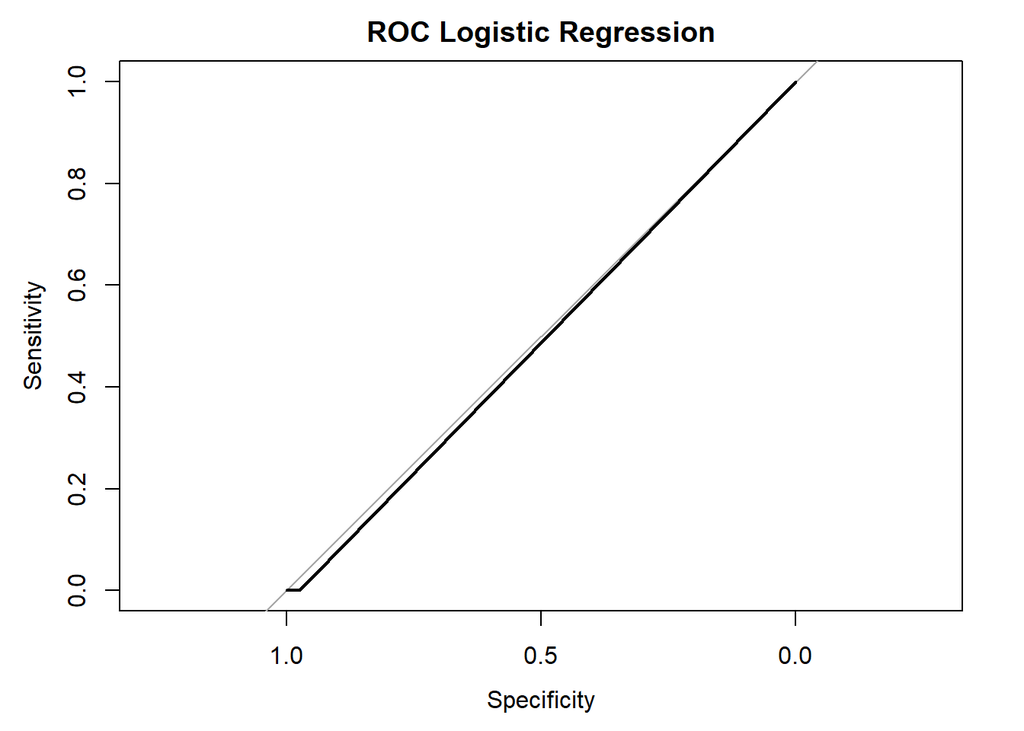

```r
roc_glm = roc(val_input$IsDefaulted, glm_val)

plot(roc_glm, main = "ROC Logistic Regression")
```

LDA:

LDA Validation classification accuracy:

```r
lda_val = predict(lda_train, val_input)

mean(lda_val$class == val_input$IsDefaulted)
```

```
## [1] 0.7651822
```

```r
lda_val = lda_val$class %>% as.integer()

roc_lda = roc(val_input$IsDefaulted, lda_val)
```

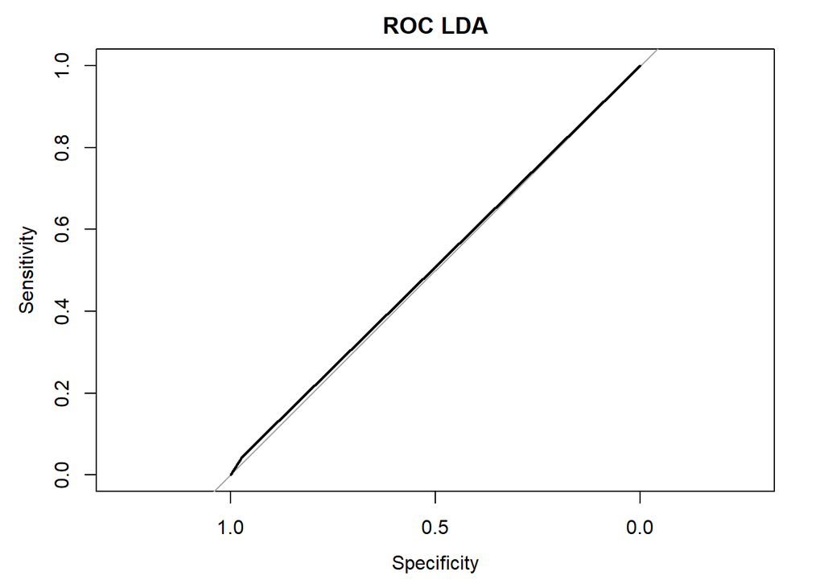

```r
plot(roc_lda, main = "ROC LDA")
```

Naive-Bayes:

Validation Classification accuracy:

```r
nb_val = predict(nb_train, val_input)

mean(nb_val == val_input$IsDefaulted)
```

```
## [1] 0.888664
```

```r
nb_val_int = nb_val %>% as.integer()

roc_nb = roc(val_input$IsDefaulted, nb_val_int)
```

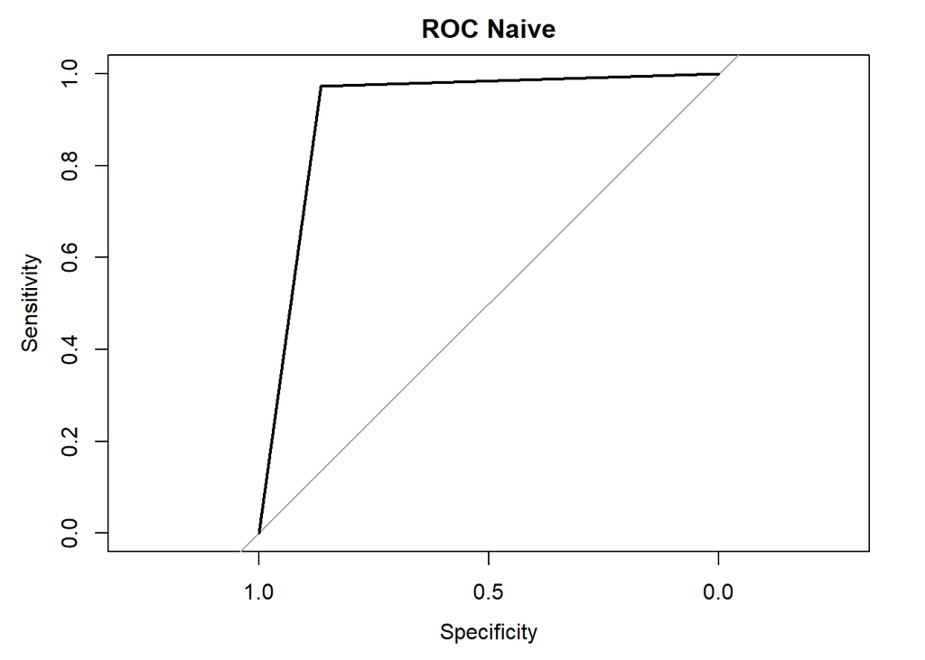

```r
plot(roc_nb, main = "ROC Naive")
```

GAM:

Validation classification accuracy:

```r
gam_val = predict(train_gam, val_input)

gam_val= ifelse(gam_val > 0.50, 1, 0)

mean(gam_val == val_input$IsDefaulted)
```

```
## [1] 0.757085
```

```r
roc_gam = roc(val_input$IsDefaulted, gam_val)
```

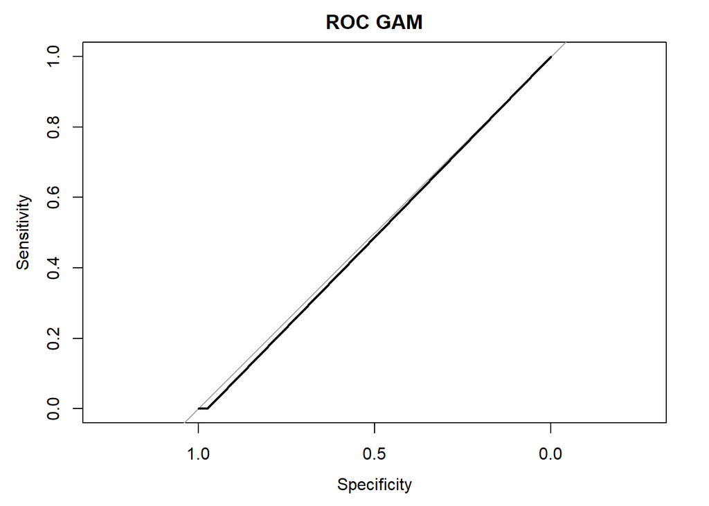

```r
plot(roc_gam, main = "ROC GAM")
```

# Final predictions

Training naiveBayes model on full data

```r
nb_test = naiveBayes(IsDefaulted ~ ., data = scale_df)
```

```r
nb_final = predict(nb_test, scale_test_df)
```

Getting the predictions into the correct format to be submitted on Zindi

```r
test_transac_id = test %>% na.omit()

final_subm = cbind(test_transac_id$TransactionId, as.factor(nb_final))

colnames(final_subm) = c("TransactionId", "IsDefaulted")

final_df = as.data.frame(final_subm)

final_df$IsDefaulted = ifelse(final_df$IsDefaulted == 1, 0, 1)

final_df %>% head()
```

|  | TransactionId | IsDefaulted |
| --- | --- | --- |
| 1 | TransactionId_925 | 0 |
| 2 | TransactionId_1080 | 0 |
| 3 | TransactionId_2315 | 0 |
| 4 | TransactionId_1466 | 0 |
| 5 | TransactionId_337 | 0 |
| 6 | TransactionId_875 | 0 |